# :Lab 12

# 3 Parts: t-test & chi-square followup, basic regression commands (preview), and confidence intervals

## Following up on t-test

In R, there are two related t-test functions: qt() and t.test

qt is the t-distribution equivalent of qnorm, qbinom, etc. It’s for finding the “quantile” of a particular probability. Or, in hypothesis testing terms, it’s for finding the critical value for a given alpha or p-value. The format is qt(p-value,degrees of freedom)

the t.test() function actually runs a t-test. Ideally, you just have a data frame named “x” that has group1 in one column and groupb in the other with nothing else. In that case, you just use:

t.test(x, alternative hypothesis, paired = FALSE/TRUE)

for paired or true, you pick one or the other. If you don’t specify, it defaults to false.

For alternative hypothesis, pick a choice from the possibilities in c: alternative = c(“two.sided”, “less”, “greater”)

So, for example, for the problem in the quiz and examples:

t.test(some_data_frame_name, alternative = “two.sided”, paired = TRUE)

Chi-square also has two functions:

qchisq() is the quantile and chisq.test performs the test on some data.

qchisq() which requires just p for probability and df for degrees of freedom. [full format is qchisq(p, df, ncp = 0, lower.tail = TRUE, log.p = FALSE where the default values show for everything but p and df. You can leave out the things with defaults unless you know you need something other than the default.)

chisq.test() requires either two vectors or a matrix. For our purposes you will also need to include correct = FALSE. So the format for our purposes would be:

chisq.test(data_frame_name, correct = FALSE)

This is assuming the data frame has only the data you want to run the chi-square test on. Otherwise:

chisq.test(x,y,correct = FALSE) where x and y are vectors of equal length

## Preview of linear regression (OLS)

For your projects, you’ll be doing OLS regression of your data. We’ll be covering the theory of OLS tomorrow and the interpretation of results on Thursday. For those of you who want to start the basic coding, we’ll cover that now and look at it again later in the week.

```r
# First we need some data
# We'll use the built in USArrests data
my_data <- data.frame(USArrests)
head(my_data)
```

|  | Murder | Assault | UrbanPop | Rape |
| --- | --- | --- | --- | --- |
| Alabama | 13.2 | 236 | 58 | 21.2 |
| Alaska | 10.0 | 263 | 48 | 44.5 |
| Arizona | 8.1 | 294 | 80 | 31.0 |
| Arkansas | 8.8 | 190 | 50 | 19.5 |
| California | 9.0 | 276 | 91 | 40.6 |
| Colorado | 7.9 | 204 | 78 | 38.7 |

```r
NA
```

The basic format is that we create an object to hold our model, then assign the OLS function - lm() using the assignment operator.

Then typically we run the summary() command on the object containing the model.

I’ll do this once just to demonstrate this, then go into details of the lm function.

```r
#Creating a model named "model1"
model1 <- lm(Murder ~ UrbanPop, data = my_data)

#The model is now in the model object - we #need to get the information to the screen - #the best way is usually with summary()
summary(model1)
```

```
Call:
lm(formula = Murder ~ UrbanPop, data = my_data)

Residuals:
   Min     1Q Median     3Q    Max
-6.537 -3.736 -0.779  3.332  9.728

Coefficients:
            Estimate Std. Error t value Pr(>|t|)
(Intercept)  6.41594    2.90669   2.207   0.0321 *
UrbanPop     0.02093    0.04333   0.483   0.6312
---
Signif. codes:  0 ‘***’ 0.001 ‘**’ 0.01 ‘*’ 0.05 ‘.’ 0.1 ‘ ’ 1

Residual standard error: 4.39 on 48 degrees of freedom
Multiple R-squared:  0.00484,   Adjusted R-squared:  -0.01589
F-statistic: 0.2335 on 1 and 48 DF,  p-value: 0.6312
```

This produced a lot of information, which we will spend most of a day on. For now - it worked!

So, the stuff inside the lm()…

We are asking R to find the equation

$y = \alpha + \beta X + \epsilon$

In the next example, I’m going to tell R that my y is Assaults and my x is Urban Population.

```r
#model2 is just creating an object called model2 to hold the model
# <- assignment operator
# lm() function
# Assault is the y, the left hand side of the #equation I am asking R to create
# ~ goes into most R formulas in the place #where the model equation has its equal sign
# UrbanPop to the right of the equal sign is #to the right of the ~
# I tell it that my data is coming from #my_data. Otherwise, I would have to do the #variables in the format my_data$Assault
model2 <- lm(Assault ~ UrbanPop, data = my_data)

#summary command
summary(model2)
```

```
Call:
lm(formula = Assault ~ UrbanPop, data = my_data)

Residuals:
    Min      1Q  Median      3Q     Max
-150.78  -61.85  -18.68   58.05  196.85

Coefficients:
            Estimate Std. Error t value Pr(>|t|)
(Intercept)  73.0766    53.8508   1.357   0.1811
UrbanPop      1.4904     0.8027   1.857   0.0695 .
---
Signif. codes:  0 ‘***’ 0.001 ‘**’ 0.01 ‘*’ 0.05 ‘.’ 0.1 ‘ ’ 1

Residual standard error: 81.33 on 48 degrees of freedom
Multiple R-squared:  0.06701,   Adjusted R-squared:  0.04758
F-statistic: 3.448 on 1 and 48 DF,  p-value: 0.06948
```

```r
library(stargazer)
stargazer(model2, type = "text")
```

```
===============================================
                        Dependent variable:
                    ---------------------------
                              Assault
-----------------------------------------------
UrbanPop                      1.490*
                              (0.803)

Constant                      73.077
                             (53.851)

-----------------------------------------------
Observations                    50
R2                             0.067
Adjusted R2                    0.048
Residual Std. Error      81.331 (df = 48)
F Statistic             3.448* (df = 1; 48)
===============================================
Note:               *p<0.1; **p<0.05; ***p<0.01
```

## Confidence intervals

```r
#We need a data frame to apply the model to that has the value we want for UrbanPop (90)
new_data <- data.frame(UrbanPop = 90)

#The predict function takes the model, the data we give it, and produces a prediction
# interval = "confidence" tells it to include a confidence interval
predict(model2,new_data, interval = "confidence")
```

```
       fit      lwr      upr
1 207.2162 161.4647 252.9676
```

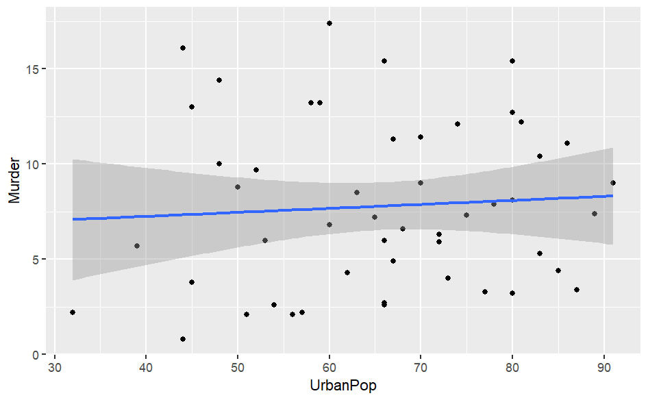

```r
library(ggplot2)

#create scatterplot with fitted regression line
ggplot(my_data, aes(UrbanPop, Murder)) +
  geom_point() +
  stat_smooth(method = "lm")
```